# Lab 3 Possion

# Exercise 2

Use the function mcmc_areas() to plot the smoothed posterior distribution for λ with a 90% Highest Posterior Density region. Changing the prob parameter in mcmc_areas() will change the amount of probability mass that is highlighted. The highlighted region will begin in regions of highest density, and will move towards regions of lower density as prob gets larger.

The line in the plot represents the posterior mean, and the shaded area represents 90% of the posterior density. How does the posterior mean for λ compare to the sample mean? Are they similar or not? Why are they different?

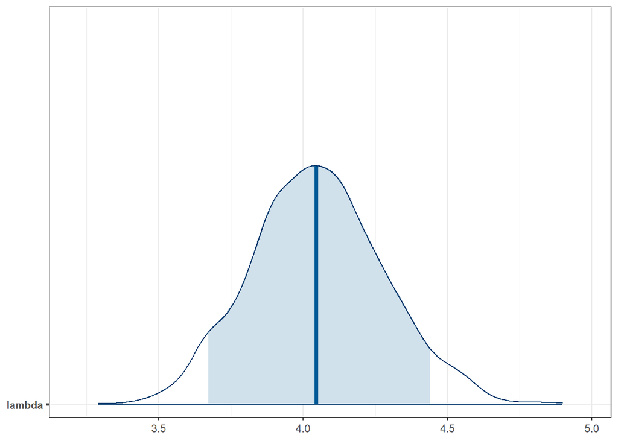

```r
mcmc_areas(lambda_draws, prob = 0.9)
```

```r
print(fit, pars = "lambda")
```

```
## Inference for Stan model: anon_model.
## 2 chains, each with iter=2000; warmup=1000; thin=1;
## post-warmup draws per chain=1000, total post-warmup draws=2000.
##
##        mean se_mean   sd 2.5% 25% 50% 75% 97.5% n_eff Rhat
## lambda    4    0.01 0.23  3.6 3.9   4 4.2   4.5   758    1
##
## Samples were drawn using NUTS(diag_e) at Thu Feb  8 15:09:11 2024.
## For each parameter, n_eff is a crude measure of effective sample size,
## and Rhat is the potential scale reduction factor on split chains (at
## convergence, Rhat=1).
```

```r
mean(countdeath)
```

```
## [1] 4
```

Answer: Since mean of sample is 4, the posterior mean actually becomes larger. They are simlar; because the prior has a larger mean (5).

# Exercise 3

```r
m=length(lambda_draws)
y_rep <- matrix(rpois(m * n, lambda =mean(lambda_draws)), nrow = m, ncol = n)
```

# Exercise 4

# Exercise 5

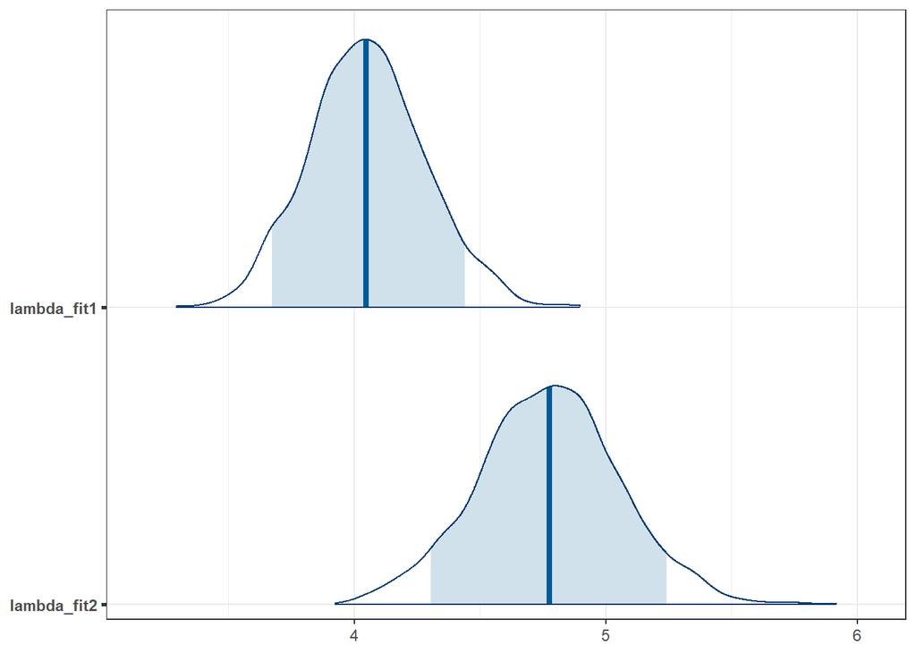

```r
stan_dat <- list(y = y, N = n)
fit2 <- stan("lab-03-poisson-hurdle.stan", data = stan_dat, refresh = 0, chains = 2)


lambda_draws2 <- as.matrix(fit2, pars = "lambda")
# Compare
lambdas <- cbind(lambda_fit1 = lambda_draws[, 1],
                 lambda_fit2 = lambda_draws2[, 1])

# Shade 90% interval
mcmc_areas(lambdas, prob = 0.9)
```

```r
y_rep2 <- as.matrix(fit2, pars = "y_rep")
```

# Exercise 6 PPC new

Answer: From the PPC results below, we could notice that in hurdle model a random variable is modelled using two parts, the first which is the probability of attaining value 0, and the second part models the probability of the non-zero values. The use of hurdle models are often motivated by an excess of zeroes in the data, that is not sufficiently accounted for in more standard statistical models.

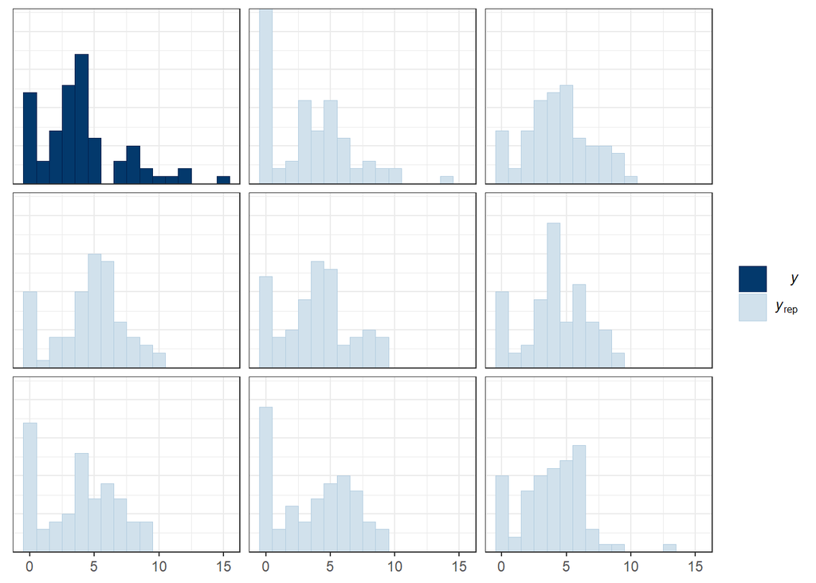

```r
ppc_hist(y, y_rep2[1:8, ], binwidth = 1)
```

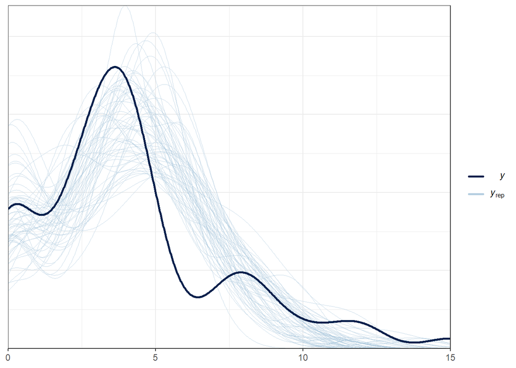

```r
ppc_dens_overlay(y, y_rep2[1:60, ])
```

```r
prop_zero <- function(x){
  mean(x == 0)
}
prop_zero(y)
```

```
## [1] 0.16
```

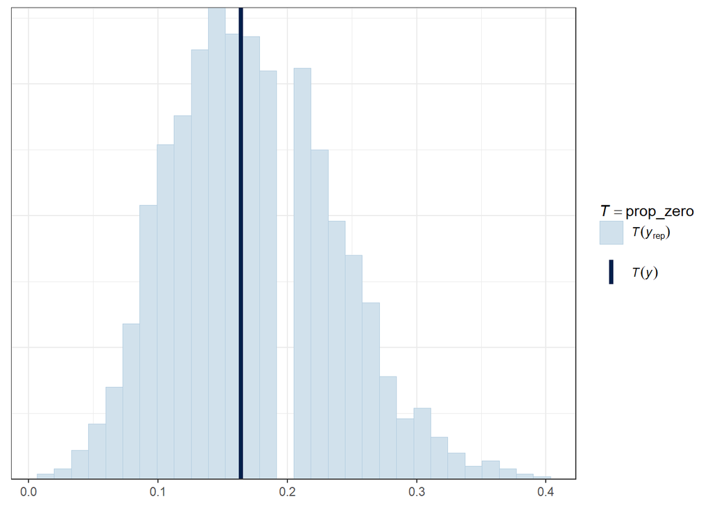

```r
ppc_stat(y, y_rep2, stat = "prop_zero")
```

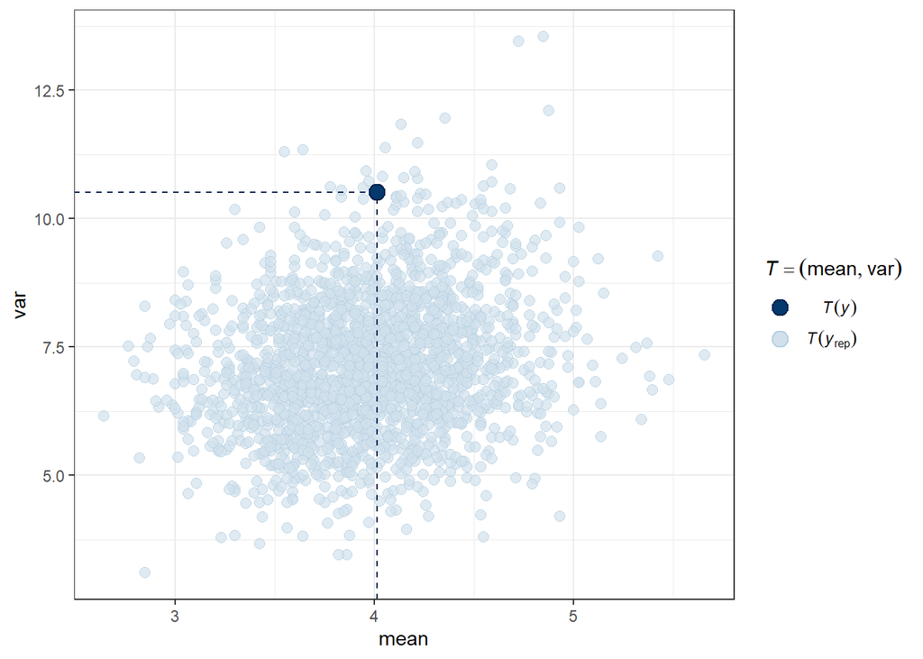

```r
ppc_stat_2d(y, y_rep2, stat = c("mean", "var"))
```

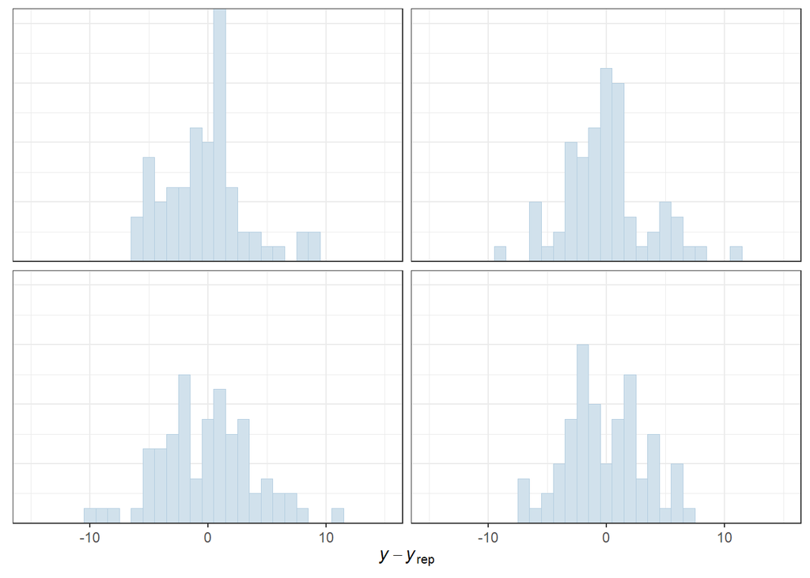

```r
ppc_error_hist(y, y_rep[1:4, ], binwidth = 1) + xlim(-15, 15)
```

# Exercise 7: LOOCV

Answer: From the code below, for “elpd_diff” and “se_diff”, we can see model 2 fits better.

```r
log_lik1 <- extract_log_lik(fit, merge_chains = FALSE)
r_eff1 <- relative_eff(exp(log_lik1))
(loo1 <- loo(log_lik1, r_eff = r_eff1))
```

```
##
## Computed from 2000 by 73 log-likelihood matrix
##
##          Estimate   SE
## elpd_loo   -203.1 14.5
## p_loo         2.4  0.5
## looic       406.2 29.0
## ------
## Monte Carlo SE of elpd_loo is 0.1.
##
## All Pareto k estimates are good (k < 0.5).
## See help('pareto-k-diagnostic') for details.
```

```r
##
## Computed from 2000 by 73 log-likelihood matrix
##
##          Estimate   SE
## elpd_loo   -203.2 14.6
## p_loo         2.6  0.5
## looic       406.4 29.2
## ------
## Monte Carlo SE of elpd_loo is 0.1.
##
## All Pareto k estimates are good (k < 0.5).
## See help('pareto-k-diagnostic') for details.
log_lik2 <- extract_log_lik(fit2, merge_chains = FALSE)
r_eff2 <- relative_eff(exp(log_lik2))
(loo2 <- loo(log_lik2, r_eff = r_eff2))
```

```
##
## Computed from 2000 by 73 log-likelihood matrix
##
##          Estimate   SE
## elpd_loo   -183.3 10.8
## p_loo         2.8  0.5
## looic       366.5 21.7
## ------
## Monte Carlo SE of elpd_loo is 0.0.
##
## All Pareto k estimates are good (k < 0.5).
## See help('pareto-k-diagnostic') for details.
```

```r
##
## Computed from 2000 by 73 log-likelihood matrix
##
##          Estimate   SE
## elpd_loo   -183.2 10.8
## p_loo         2.7  0.4
## looic       366.4 21.6
## ------
## Monte Carlo SE of elpd_loo is 0.0.
##
## All Pareto k estimates are good (k < 0.5).
## See help('pareto-k-diagnostic') for details.
loo_compare(loo1, loo2)
```

```
##        elpd_diff se_diff
## model2   0.0       0.0
## model1 -19.8       8.5
```

```r
##        elpd_diff se_diff
## model2   0.0       0.0
## model1 -20.0       8.5
```

# Exercise 8: Why are PPCs important?

PPCs allow you to compare observed data with data simulated from your model.Graphical PPCs can help in identifying specific ways in which your model might not be a good fit for the data, and it could help you choose among models.

# Exercise 9: Was the second model a good fit for the data? Why or why not? Summarize your findings in both the PPCs as well as the LOOCV.

The second model fits the data. In PPC, it generates picture similar to the model. In LOOCV, it will cause lower error.

# Exercise 10: If someone reported a single LOOCV error to you, would that be useful? Why or why not?

This could not be quite useful; It maybe overfitting.

# R tutorials and resources

For more information on the R programming language please refer to some or all of the following resources:

- [R for Data Science](https://r4ds.had.co.nz/)
- [ggplot2](https://ggplot2.tidyverse.org/)
- [ColorBrewer](http://colorbrewer2.org/)

# Acknowledgement

This lab was created by [Jordan Bryan](https://scholars.duke.edu/person/jordan.bryan) and [Becky Tang](https://scholars.duke.edu/person/becky.tang).